# Reproducible Research: Peer Assessment 1

## Loading and preprocessing the data

```r
setwd("~/Rfiles")
unzip("./RepData_PeerAssessment1/activity.zip", exdir="./RepData_PeerAssessment1/ActivityData")
actData <- read.csv("./RepData_PeerAssessment1/ActivityData/activity.csv")
actDataClean <- na.omit(actData)
```

As-01,10-08, 11-01, 11-04, 11-09, 11-10, 11-14 and 11-30 contain only NA values for steps taken, these dates are excluded from the dataset “actDataClean”.

## What is mean total number of steps taken per day?

```r
library(plyr)
x <- ddply(actData,~date,summarise,totalSteps=sum(steps))
mean(na.omit(x$totalSteps))
```

```
## [1] 10766.19
```

```r
median(na.omit(x$totalSteps))
```

```
## [1] 10765
```

```r
print(x)
```

```
##          date totalSteps
## 1  2012-10-01         NA
## 2  2012-10-02        126
## 3  2012-10-03      11352
## 4  2012-10-04      12116
## 5  2012-10-05      13294
## 6  2012-10-06      15420
## 7  2012-10-07      11015
## 8  2012-10-08         NA
## 9  2012-10-09      12811
## 10 2012-10-10       9900
## 11 2012-10-11      10304
## 12 2012-10-12      17382
## 13 2012-10-13      12426
## 14 2012-10-14      15098
```

[output cut: 47 more lines]

## What is the average daily activity pattern?

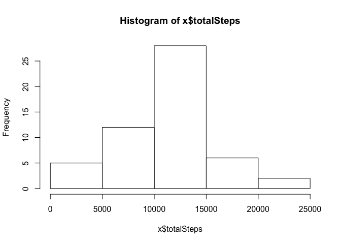

```r
hist(x$totalSteps)
```

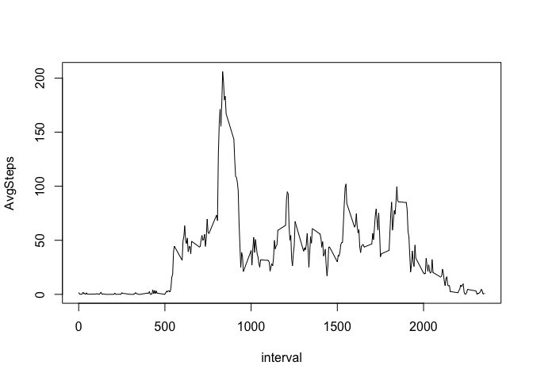

```r
y <- ddply(actDataClean,~interval,summarise,AvgSteps=mean(steps))
plot(y, type="l")
```

```r
y$interval[[which.max(y$AvgSteps)]]
```

```
## [1] 835
```

Interval 835 has the highest average steps value, seen clearly in the line graph above cresting over 200 steps.

## Imputing missing values

```r
summary(actData)
```

```
##      steps                date          interval
##  Min.   :  0.00   2012-10-01:  288   Min.   :   0.0
##  1st Qu.:  0.00   2012-10-02:  288   1st Qu.: 588.8
##  Median :  0.00   2012-10-03:  288   Median :1177.5
##  Mean   : 37.38   2012-10-04:  288   Mean   :1177.5
##  3rd Qu.: 12.00   2012-10-05:  288   3rd Qu.:1766.2
##  Max.   :806.00   2012-10-06:  288   Max.   :2355.0
##  NA's   :2304     (Other)   :15840
```

There are 2304 NAs in the Dataset.

```r
actDataFull <- actData
actDataFull[is.na(actDataFull)] <- mean(y$AvgSteps)
```

Replaced all missing values with the mean for all intervals, about 37.

```r
z <- ddply(actDataFull,~date,summarise,totalSteps=sum(steps))
mean(z$totalSteps)
```

```
## [1] 10766.19
```

```r
median(z$totalSteps)
```

```
## [1] 10766.19
```

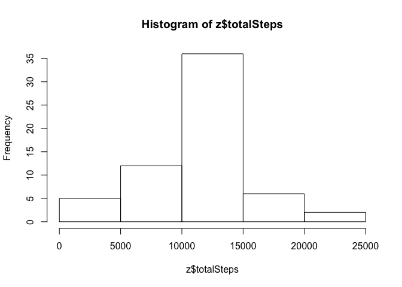

```r
hist(z$totalSteps)
```

Imputing the missing values by replacing them with the interval mean did not affect the mean, though it did make the median equivalent to the mean. As a result, the distribution of the imputed data looks more normally distributed.

## Are there differences in activity patterns between weekdays and weekends?

```r
actDataFull$date <- as.POSIXct(actDataFull$date)
actDataFull$Day <- factor(weekdays(actDataFull$date))
actDataFull$Day <- revalue(actDataFull$Day, c("Friday"="Weekday", "Monday"="Weekday", "Thursday"="Weekday", "Tuesday"="Weekday", "Wednesday"="Weekday", "Saturday"="Weekend", "Sunday"="Weekend"))
```

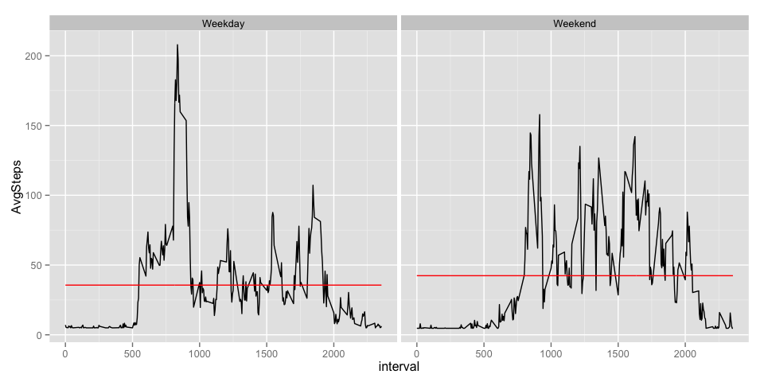

```r
ab <- ddply(actDataFull,.(Day, interval),summarise,AvgSteps=mean(steps))
library(ggplot2)
g <- ggplot(ab, aes(interval, AvgSteps))
g + geom_line() + facet_grid(.~Day) + geom_line(stat = "hline", yintercept = "mean", col="red")
```

At first glance, weekdays appear to have a larger number of steps, however, we can see that the mean steps taken is slightly higher on wekeends. It appears that a single high average value is pushing weeekday steps higher. Perhaps this is a morning walk to work that doesn’t occur on weekends?